# p8105_hw1_xg2451

Xuanyu Guo

2024-09-17

# Problem 1

```r
# load the penguins dataset
data("penguins", package = "palmerpenguins")
```

The `penguins` dataset includes several variables about penguin measurements and observations such as species, island, bill length (mm), bill depth (mm), flipper length (mm), body mass (g), sex and study year.

The dataset has 344 rows and 8 columns.

The mean flipper length across all penguins in the dataset is 200.9152047 mm.

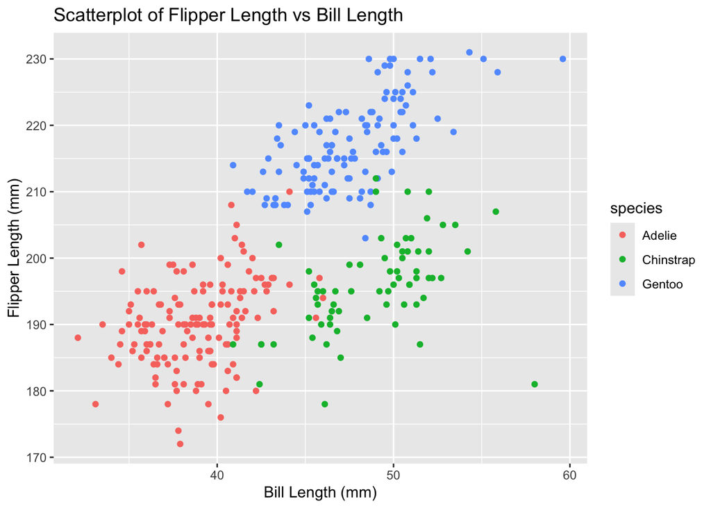

```r
# Make a scatterplot of flipper_length_mm (y) vs bill_length_mm (x); color points using the species variable
library(ggplot2)
penguins <- na.omit(penguins)  # Remove rows containing missing values

p <- ggplot(penguins, aes(x = bill_length_mm, y = flipper_length_mm, color = species)) +
  geom_point() +
  labs(title = "Scatterplot of Flipper Length vs Bill Length",
       x = "Bill Length (mm)",
       y = "Flipper Length (mm)")
p
```

```r
# Export scatterplot to project directory using ggsave
ggsave("penguins_scatterplot.png", plot = p, width = 10, height = 8)
```

# Problem 2

```r
set.seed(123)  # Setting seed for reproducibility
normal_sample = rnorm(10) # Random 10 samples from a standard Normal distribution
is_positive = normal_sample > 0 # Logical vector: TRUE if sample > 0

df <- data.frame(
  normal_sample,
  is_positive,
  characters = letters[1:10],  # Character vector of length 10
  factors = factor(rep(1:3, length.out = 10))  # Factor vector with 3 levels
)
```

```r
library(tidyverse)
mean_normal <- mean(pull(df, normal_sample), na.rm = TRUE)
mean_is_positive <- mean(pull(df, is_positive), na.rm = TRUE)
# mean_characters <- mean(pull(df, characters), na.rm = TRUE)  # This will throw an error
# mean_factors <- mean(pull(df, factors), na.rm = TRUE)  # This will also throw an error
```

Taking the mean works for `normal_sample` as it contains numeric values, and for `is_positive` as logical values are coerced to numeric (FALSE as 0 and TRUE as 1). However, it does not work for `characters` or `factors` because character and factor data types do not inherently represent numeric values.

```r
# show this chunk but not the output
numeric_from_logical <- as.numeric(pull(df, is_positive))
numeric_from_character <- as.numeric(pull(df, characters))
numeric_from_factor <- as.numeric(pull(df, factors))
```

- **Logical to Numeric**: Coercion is straightforward; `TRUE` becomes 1 and `FALSE` becomes 0.
- **Character to Numeric**: Coercion results in `NA` because character strings do not have inherent numeric values.
- **Factor to Numeric**: Coercion turns factor levels into their underlying integer codes.

This explains why taking the mean of the original `characters` and `factors` columns fails. Characters cannot be coerced into meaningful numeric values, and while factors can be coerced to their integer representations, these integers don’t necessarily represent meaningful numeric data for operations like mean.